Skip to poster content

UIST 2026 Doctoral Symposium poster

# Visual Communication for Low-Vision Information Access: From Personalized Highlights to AI Agents

Yotam Sechayk, The University of Tokyo

- [Doctoral Symposium paper (ACM Digital Library)](https://doi.org/10.1145/3830397.3841706)
- yotam@sechayk.com
- sechayk.com
- Blog post about this research

**My thesis.** Personalized AI that **communicates visually**, supporting the **independence and agency** of low-vision people.

## About me

**Yotam Sechayk**, PhD candidate at the University of Tokyo, Igarashi Lab. BS in Computer Science and Film, Tel Aviv University; MSc, University of Tokyo. **Graduating March 2027.**

“Motivated by my lived experience with low vision”

## Motivation

**295 million** people have low vision, and many prefer using their **residual vision**. Yet most research turns visuals into other modalities like speech or touch. Magnification techniques support residual vision, but they **fragment the view** and increase cognitive effort.

How can we communicate visual information in a visually accessible way?

## Two directions of visual communication

- Tool → UserProjects 1 and 2

  Tools that **visually communicate visual information** to users, making the experience of visual perception accessible.
- User → AIProject 3

  Users **communicate visually with AI tools** by sharing their view or indicating a point of interest, and get personalized support based on how they use their assistive tools.
- Both waysProject 4 (future)

  AI systems that **share the user’s visual context** and also **communicate visually** with users, making visuals visually accessible.

Towards **ability-based AI systems** that build on the residual vision and assistive tool use of people with low vision, for **personalized, in-situ visual support** through visuals.

## Project 1: VeasyGuide

Published at ASSETS 2025 · Direction: Tool → User · [Paper](https://doi.org/10.1145/3663547.3746372)

[figure not shown]

Problem. Instructors visually communicate by pointing, marking, or sketching on slides, but this communication is often hard to access and follow for people with low vision.

Approach. Personalized highlights that follow instructor actions, co-designed with 3 low-vision partners.

Result. Learners noticed **88%** of actions vs 61% without, with lower cognitive load, and more agency.

Lesson. Making visual communication accessible using visual cues aids **both low-vision and sighted** learners.

## Project 2: On-Cursor Visual Context

Published at CHI 2026 · Direction: Tool → User · [Paper](https://doi.org/10.1145/3772318.3791165)

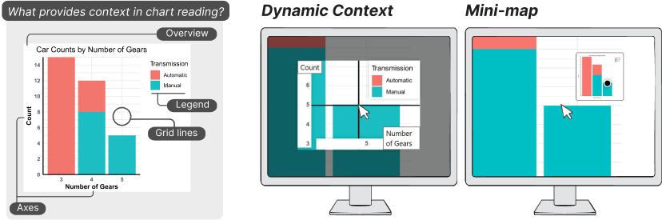

Problem. Magnification makes chart details visible, but out-of-view context is fragmented and hard to access.

Approach. Bring chart context to the pointer: Dynamic Context and Mini-map project context (axes, legend, grid lines, overview) around it.

Result. For 22 low-vision participants, Dynamic Context **improved access and reduced effort**.

Lesson. There is a **delicate tradeoff** between visual information cues and overwhelming amount of visuals.

## Project 3: Visual Context for AI

Ongoing · Direction: User → AI

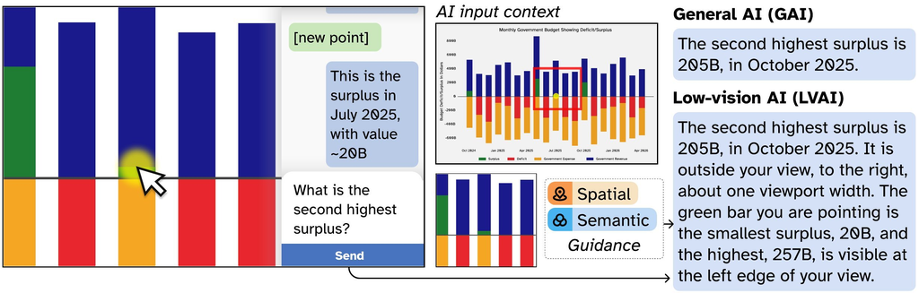

Answers to “What is the second highest surplus?”

**General AI (GAI):** “The second highest surplus is 205B, in October 2025.”

**Low-vision AI (LVAI):** “The second highest surplus is 205B, in October 2025. It is outside your view, to the right, about one viewport width. The green bar you are pointing is the smallest surplus, 20B, and the highest, 257B, is visible at the left edge of your view.”

Idea. Visual communication as context for AI agents, with responses adapted to low vision, grounded in that context.

### How it works

1. **User shows** their magnified view, pointer, and intent.
2. **AI connects** that view to the full chart, and reasons on it.
3. **AI response** is adapted to low vision, relative to their view.

Lesson. Grounding the AI in the user’s view is **necessary, but not sufficient**: its answers should also adapt to specific low-vision needs.

## Project 4: Visual Dialogue with AI

Future work · Direction: Both ways

### Open questions

**Tell, highlight, guide, or show?**

Which visual feedback fits which user and task?

**Independence or dependence?**

Does visual dialogue with AI breed a new dependence?

**How do we measure agency?**

Would AI create a new type of AI-supported agency?

### Next: the AI answers visually

- Highlight a region
- Guide along a path
- Move the view

Making visual communication visually accessible for people with low vision and beyond.